# Sample Application Use Case on Shiny For Developing Data Product Course Project

Raul Goycoolea

July 26, 2015

# Introduction

The objective of this presentation is to Introduce a Sample Data Analisis, manipulation and display on a frendly and easy to use Web Application.

The sample Applications shows a basic Data set creating tool where the user can select size and repetions.

Also you will be able to select the Distribution Type, and the application will update automatically the Graps generated. You don’t need to understand the R code that is behind the app. You only need to select the options, then the app runs the analysis code and update the results on the web.

As an add-on the Application has a “Download Sample Set” button, so the user can download a file to their own computer in a CSV format. On this way the user can review and do some analisis on the same data set locally for example on Excel.

# Application Overview

- Choose Sample Data Distribution Type from:

Regular Uniform Logarithmic normal Exponential

- Clik on “Download Sample Set” if you like to have a CSV file downloaded to your computer
- You can Select a Sample Size from 1 to 300, and a Number of Repetitions from 1 to 10,000.
- Finally there’s a “Generate New Data Set” so you can generate new data with the selected size and repetions

# Slide with R Code and Output

```r
library(RCurl)
URL <- "https://s3.amazonaws.com/sdata141512/300.csv"
x <- getURL(URL)
out <- read.csv(textConnection(x))
summary(out)
```

```
##        X                x
##  Min.   :  1.00   Min.   :-2.76888
##  1st Qu.: 75.75   1st Qu.:-0.64774
##  Median :150.50   Median :-0.01569
##  Mean   :150.50   Mean   :-0.01173
##  3rd Qu.:225.25   3rd Qu.: 0.62720
##  Max.   :300.00   Max.   : 3.13777
```

https://s3.amazonaws.com/sdata141512/300.csv

# Slide with Plot

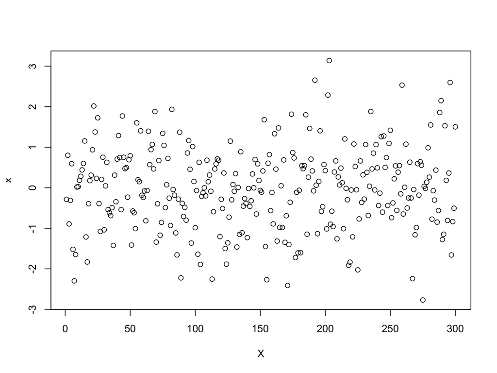